# MATH1062 Statistics

#### **Can you make any general rules about the distribution of data, and the relationship between the mean and the median depending on the shape of the histogram? Discuss this in your group and write the ideas down here.**

Median will generally be at the center of the histogram or close to it at the least. For GPA and Pulse, we see that mean and median are approximately the same as they refelct a relatively normal distribution. The same cannot be said for piercings as it is positively skewed.

**Create a new dataframe for the MathSAT scores and the bin it falls in.**

```r
# Clean and extract the MathSAT scores
x <- na.omit(student_data$MathSAT)

# Get quantile-based bin breaks (quintiles)
breaks <- quantile(x, probs = seq(0, 1, 0.2), na.rm = TRUE)

# We create a new dataframe called hist_data with only the MathSAT scores and the bin that it falls into
hist_data <- data.frame(MathSAT = x) %>%
  mutate(bin = cut(MathSAT, breaks = breaks, include.lowest = TRUE))

# Display the hist_data dataframe
hist_data
```

```
    MathSAT       bin
1       670 (630,670]
2       630 (600,630]
3       560 (550,600]
4       630 (600,630]
5       450 [400,550]
6       550 [400,550]
7       680 (670,800]
8       710 (670,800]
9       550 [400,550]
10      700 (670,800]
11      670 (630,670]
12      600 (550,600]
13      620 (600,630]
14      650 (630,670]
```

[output cut: 348 more lines]

**Create dataframe of frequencies, relative frequencies and densities for plotting**

```r
# Here we make the data frame that we will use to make the histograms
freq_table <- hist_data %>%
  count(bin) %>%            # count how many fall into the bin
  mutate(
    xmin = head(breaks, -1), # Determine the left edge of the bin
    xmax = tail(breaks, -1), # Determine the right edge of the bin
    width = xmax - xmin,     # Calculate the bin width
    rel_freq = n / sum(n),   # Relative frequency (proportion)
    density = rel_freq / width # Density
  )

freq_table
```

```
        bin  n xmin xmax width  rel_freq     density
1 [400,550] 76  400  550   150 0.2099448 0.001399632
2 (550,600] 97  550  600    50 0.2679558 0.005359116
3 (600,630] 50  600  630    30 0.1381215 0.004604052
4 (630,670] 78  630  670    40 0.2154696 0.005386740
5 (670,800] 61  670  800   130 0.1685083 0.001296218
```

**Make Frequency and Density histograms using ggplot**

```r
# Make plots using ggplot library

# Plot 1: Frequency histogram
p_freq <- ggplot(freq_table) +
  geom_rect(aes(xmin = xmin, xmax = xmax, ymin = 0, ymax = n), # Plot each rectangle, by passing in the x and y coordinates
            fill = "skyblue", color = "black") +
  scale_x_continuous(
  breaks = as.numeric(breaks),
  labels = paste0(names(breaks), "\n", as.numeric(breaks))
) +
  labs(
    title = "Frequency Histogram (Quantile Bins)",
    x = "MathSAT",
    y = "Frequency"
  ) +
  theme_minimal(base_size = 14)

# Plot 2: Density histogram
p_density <- ggplot(freq_table) +
  geom_rect(aes(xmin = xmin, xmax = xmax, ymin = 0, ymax = density), # Note here we use density for the top y-value
            fill = "tomato", color = "black") +
  scale_x_continuous(
  breaks = as.numeric(breaks),
  labels = paste0(names(breaks), "\n", as.numeric(breaks))
) +
  labs(
    title = "Density Histogram (Quantile Bins)",
    x = "MathSAT",
    y = "Density"
  ) +
  theme_minimal(base_size = 14)
```

**Frequency Histogram**

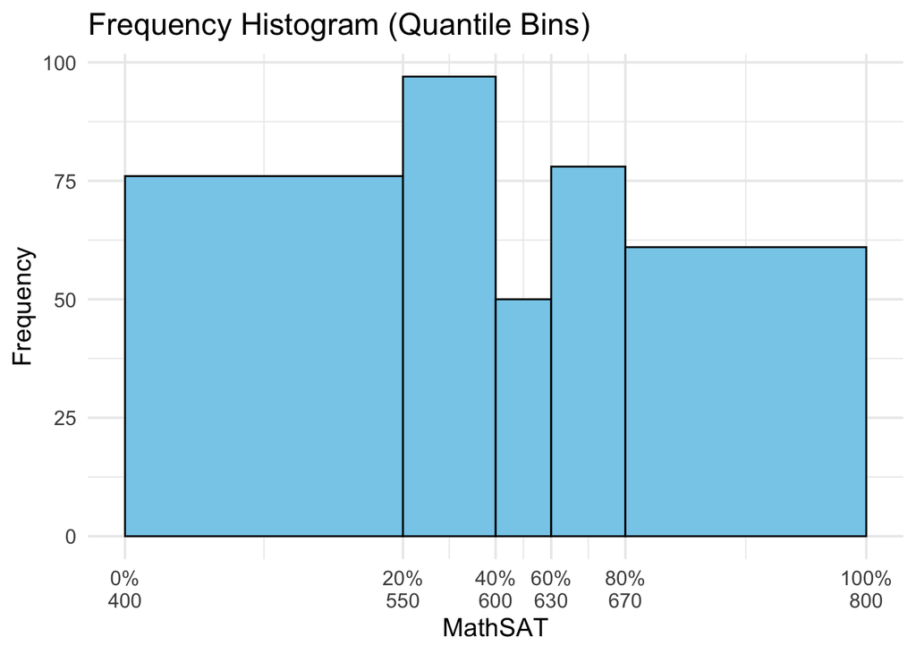

```r
# Display the frequency histogram
p_freq
```

**Density Histogram**

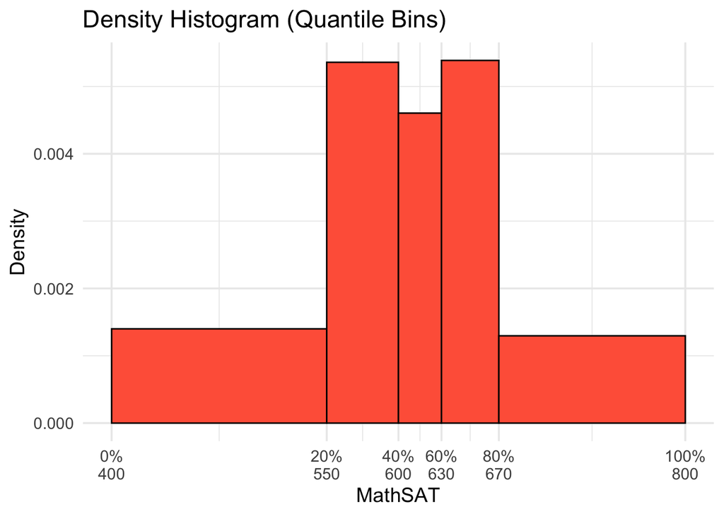

```r
# Display the density histogram
p_density
```

#### **Discuss the differences in the plots in your groups and note down the comments. Which one do you think gives a better sense of how MathSAT scores are distributed? Where is the largest concentration of MathSAT scores?**

### Scatterplots

5. Choose any two quantitative variables and hypothesize a relationship between them. Each **group** member should come up with different hypotheses. For each hypothesis, use a scatterplot to visualise their relationship. **Do a rough sketch on the board for each one**. The code example to make a scatterplot is the following

Relationship b/w Weight and Exercise: None.

```r
plot(the_data$a_variable, the_data$another_variable)
```

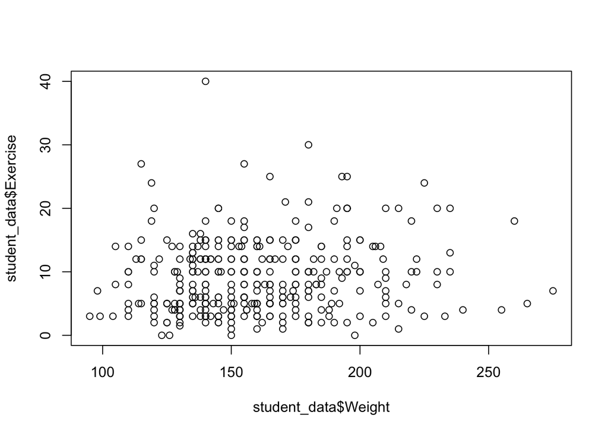

```r
plot(student_data$Weight, student_data$Exercise)
```

## Smoking Study and Simpson’s Paradox (most likely complete this after the lab)

Here we have a go at analysing another data set `simpsons_smoking.csv` and see a real life example of something called **Simpson’s paradox** (attributed to [Edward Simpson](https://en.wikipedia.org/wiki/Edward_H._Simpson), not Homer Simpson).

**Do a quick Google search or ask AI to explain what Simpson’s paradox is, then complete the remainder of the tutorial.**

[figure not shown]

Simpson on the left, not the right

This data was collected to analyse the effect of smoking on mortality rates in women. The initial data collected from an electoral roll near Newcastle in the United Kingdom. The follow-up data was collected 20 years later.

The study concentrated on 1,314 women who were either smokers or non-smokers (there are 162 who had stopped smoking and 18 did not record their status in the full data).

```r
# Read in the data set
smoking = read.csv("/Users/kierin/MATH1062/Week2/simpsons_smoking.csv", header=T)
```

Use the `str()` function to get a sense of the dimension of the data and the variables contained in the data set.

```r
str(smoking)
```

```
'data.frame':   7 obs. of  5 variables:
 $ Age               : chr  "18-24" "25-34" "35-44" "45-54" ...
 $ SmokersDied       : int  2 3 14 27 51 29 13
 $ SmokersSurvived   : int  53 121 95 103 64 7 0
 $ NonSmokersDied    : int  1 5 7 12 40 101 64
 $ NonSmokersSurvived: int  61 152 114 66 81 28 0
```

```r
# It's only a small dataset, so display the whole thing.
smoking
```

```
    Age SmokersDied SmokersSurvived NonSmokersDied NonSmokersSurvived
1 18-24           2              53              1                 61
2 25-34           3             121              5                152
3 35-44          14              95              7                114
4 45-54          27             103             12                 66
5 55-64          51              64             40                 81
6 65-74          29               7            101                 28
7   75+          13               0             64                  0
```

- Calculate the overall mortality rate (number died in group / total in group) for smokers and non-smokers by using `sum()` to sum over a variable/column and `/` to divide numbers.

  ```r
  # Mortality rate for smokers
  mortality_rate_smokers = sum(smoking$SmokersDied)/(sum(smoking$SmokersSurvived) + sum(smoking$SmokersDied))
  mortality_rate_smokers
  ```

  ```
  [1] 0.2388316
  ```

  ```r
  # Mortality rate for non-smokers
  mortality_rate_nonsmokers = sum(smoking$NonSmokersDied)/(sum(smoking$NonSmokersSurvived) + sum(smoking$NonSmokersDied))
  mortality_rate_nonsmokers
  ```

  ```
  [1] 0.3142077
  ```

#### **Write your conclusions from the calculations here:**

There is a slight but not huge difference between the mortality rate for smokers and non-smokers.

- Now let us do the same, but looking by age group. Let’s look at the mortality rates for 18-24 age groups, 45-54 age groups and 65-74 age groups. Note that the data is already summarised in these groups in a table format. To calculate the mortality rates for each group, we just need to divide the appropriate numbers in the row for each group.

**18-24 age group**

```r
# Run this code, the [1] denotes the first row of data in the data frame.
mortality_rate_smokers_18_24 = sum(smoking$SmokersDied[1])/(sum(smoking$SmokersSurvived[1]) + sum(smoking$SmokersDied[1]))
mortality_rate_smokers_18_24
```

```
[1] 0.03636364
```

```r
# Run this code
mortality_rate_nonsmokers_18_24 = sum(smoking$NonSmokersDied[1])/(sum(smoking$NonSmokersSurvived[1]) + sum(smoking$NonSmokersDied[1]))
mortality_rate_nonsmokers_18_24
```

```
[1] 0.01612903
```

**45-54 age group**

```r
mortality_rate_smokers_45_54 = sum(smoking$SmokersDied[4])/(sum(smoking$SmokersSurvived[4]) + sum(smoking$SmokersDied[4]))
mortality_rate_smokers_45_54
```

```
[1] 0.2076923
```

```r
mortality_rate_nonsmokers_45_54 = sum(smoking$NonSmokersDied[4])/(sum(smoking$NonSmokersDied[4]) + sum(smoking$NonSmokersDied[4]))
mortality_rate_nonsmokers_45_54
```

```
[1] 0.5
```

**65-74 age group**

```r
mortality_rate_smokers_65_74 = sum(smoking$SmokersDied[6])/(sum(smoking$SmokersSurvived[6]) + sum(smoking$SmokersDied[6]))
mortality_rate_smokers_65_74
```

```
[1] 0.8055556
```

```r
mortality_rate_nonsmokers_65_74 = sum(smoking$NonSmokersDied[6])/(sum(smoking$NonSmokersSurvived[6]) + sum(smoking$NonSmokersDied[6]))
mortality_rate_nonsmokers_65_74
```

```
[1] 0.7829457
```